# Kentucky Derby

Prajwal Vijendra

September 19, 2018

```r
library(tidyverse)
library(lattice)

kderby<-  read.csv("Dataset/Ex0920.csv")

head(kderby)
```

```
##   X Year        Winner Condition    Speed
## 1 1 1896     Ben Brush      good 51.66340
## 2 2 1897    Typhoon II      slow 49.81132
## 3 3 1898       Plaudit      good 51.16279
## 4 4 1899        Manuel      fast 50.00000
## 5 5 1900 Lieut. Gibson      fast 52.27723
## 6 6 1901  His Eminence      fast 51.66340
```

```r
summary(kderby)
```

```
##        X            Year                Winner   Condition     Speed
##  Min.   :  1   Min.   :1896   *Omar Khayyam: 1   fast:75   Min.   :48.82
##  1st Qu.: 27   1st Qu.:1922   *Tomy Lee    : 1   good:10   1st Qu.:52.28
##  Median : 53   Median :1948   Affirmed     : 1   slow:20   Median :53.40
##  Mean   : 53   Mean   :1948   Agile        : 1             Mean   :53.04
##  3rd Qu.: 79   3rd Qu.:1974   Alan-a-Dale  : 1             3rd Qu.:54.01
##  Max.   :105   Max.   :2000   Alysheba     : 1             Max.   :55.28
##                               (Other)      :99
```

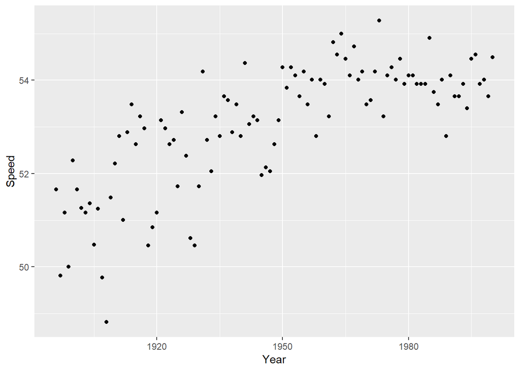

```r
ggplot(data = kderby) + geom_point(mapping = aes(x = Year, y = Speed))
```

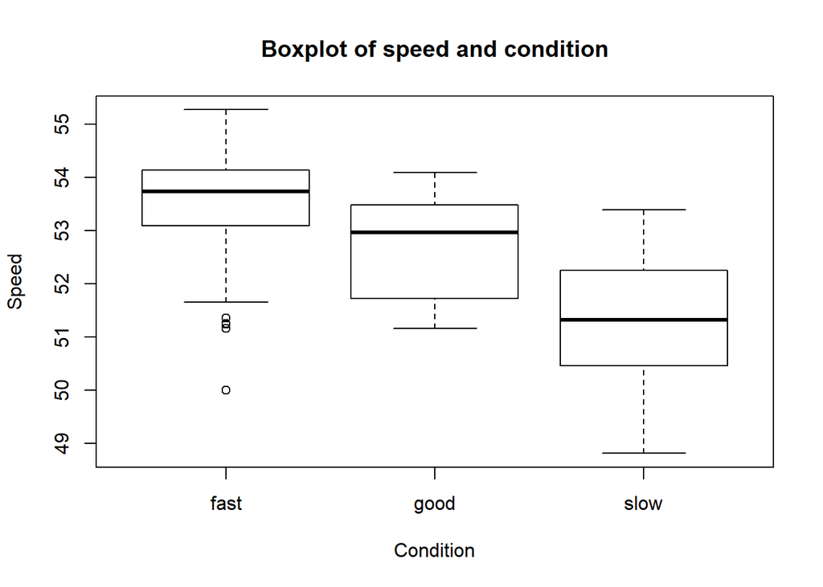

```r
boxplot(Speed~Condition, data = kderby, xlab = "Condition", ylab = "Speed", main = "Boxplot of speed and condition")
```

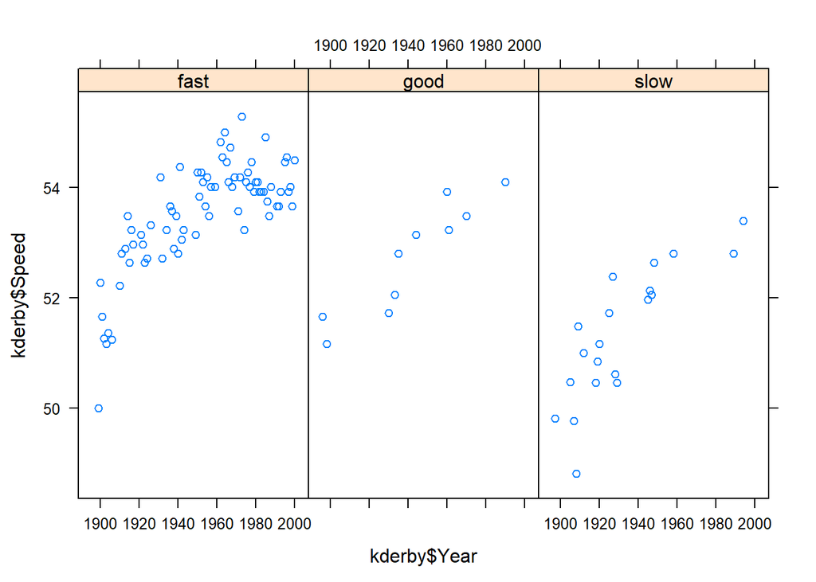

```r
xyplot(kderby$Speed~ kderby$Year | kderby$Condition)
```

Looking at the scatter plot and box plot we can see that the plots doesn’t show linearity and constant variance. May be taking the tranformation might help. We can also see from the xy plots that the slopes are similar and hence there doesn’t seem to be an intreaction effect betwwen the variables.

```r
regderby = lm(Speed ~ Year + as.factor(Condition), data= kderby)
summary(regderby)
```

```
##
## Call:
## lm(formula = Speed ~ Year + as.factor(Condition), data = kderby)
##
## Residuals:
##      Min       1Q   Median       3Q      Max
## -2.07813 -0.41881  0.07044  0.40660  1.24725
##
## Coefficients:
##                           Estimate Std. Error t value Pr(>|t|)
## (Intercept)               0.935170   4.268917   0.219   0.8270
## Year                      0.026932   0.002185  12.324  < 2e-16 ***
## as.factor(Condition)good -0.500981   0.220421  -2.273   0.0252 *
## as.factor(Condition)slow -1.615054   0.170411  -9.477 1.27e-15 ***
## ---
## Signif. codes:  0 '***' 0.001 '**' 0.01 '*' 0.05 '.' 0.1 ' ' 1
##
## Residual standard error: 0.6505 on 101 degrees of freedom
## Multiple R-squared:  0.7683, Adjusted R-squared:  0.7614
## F-statistic: 111.6 on 3 and 101 DF,  p-value: < 2.2e-16
```

```r
confint(regderby)
```

```
##                                2.5 %      97.5 %
## (Intercept)              -7.53321312  9.40355361
## Year                      0.02259661  0.03126644
## as.factor(Condition)good -0.93823768 -0.06372517
## as.factor(Condition)slow -1.95310400 -1.27700446
```

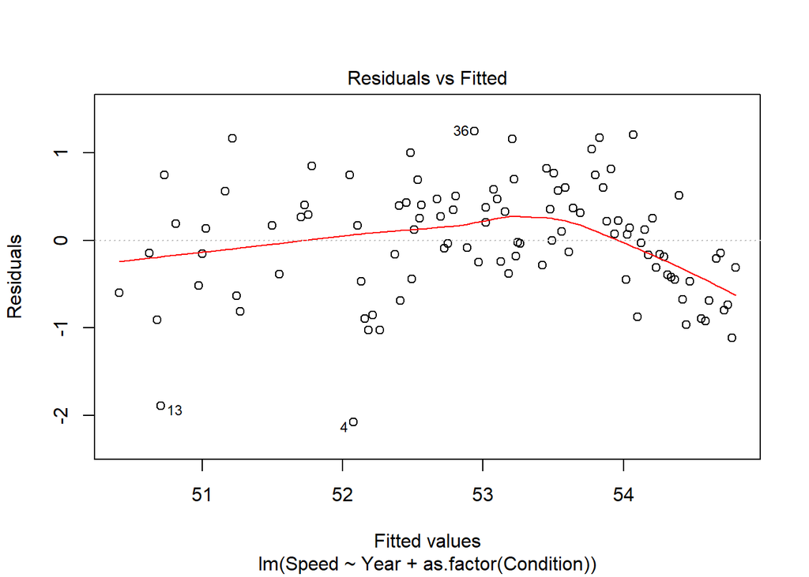

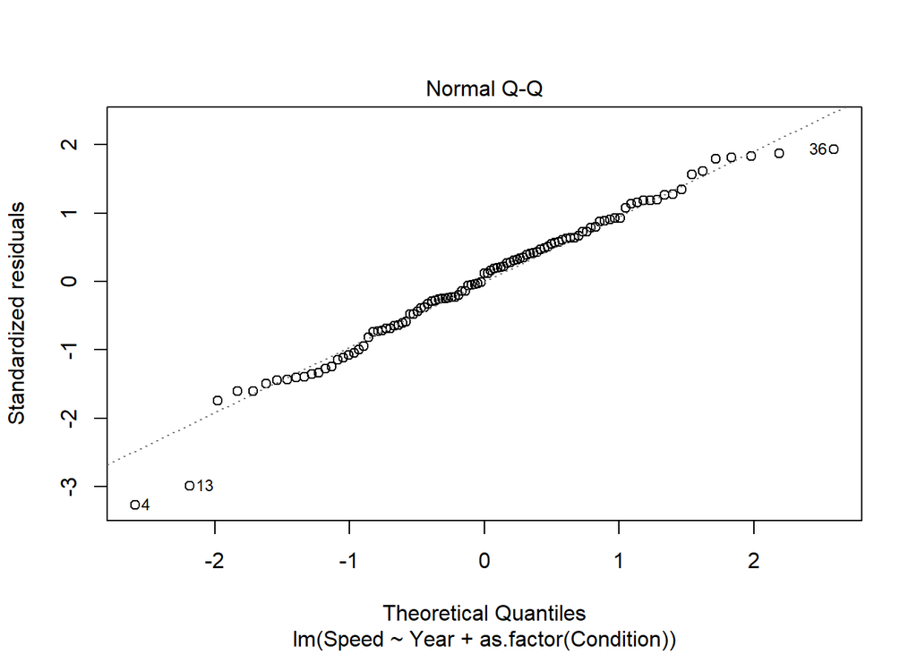

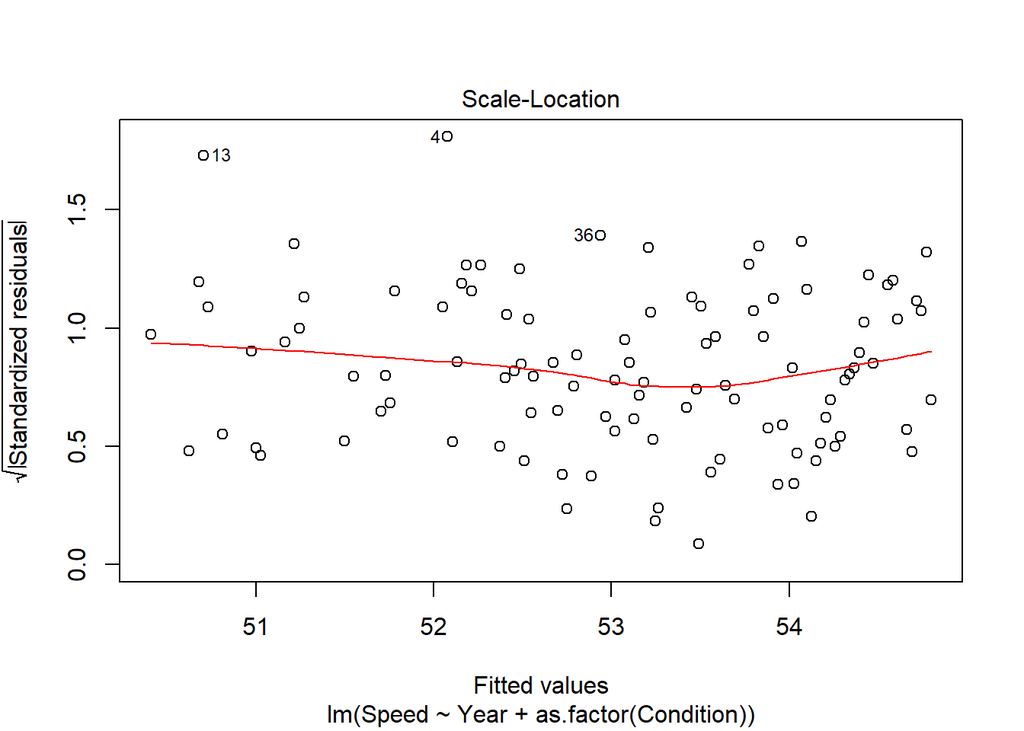

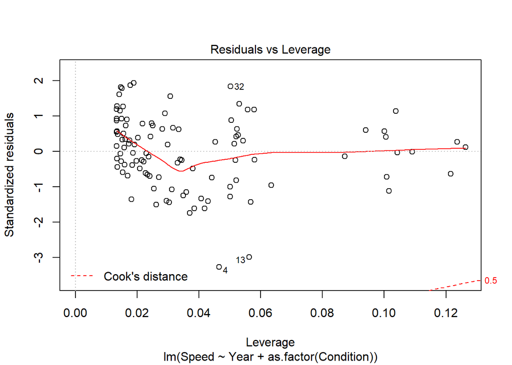

```r
plot(regderby)
```

The residual plot doesn’t show constant variance and qq plot is bent towards the beginning and the end and the residual does not exhibit normal distribution.

Lets transform and see if it is helpful.

```r
kderby$Year_C = kderby$Year - min(kderby$Year)

Year_square = kderby$Year_C^2

regderby2 = lm(Speed ~ Year_C + Year_square + as.factor(Condition), data= kderby)

summary(regderby2)
```

```
##
## Call:
## lm(formula = Speed ~ Year_C + Year_square + as.factor(Condition),
##     data = kderby)
##
## Residuals:
##      Min       1Q   Median       3Q      Max
## -1.60905 -0.30796 -0.02224  0.38851  1.10047
##
## Coefficients:
##                            Estimate Std. Error t value Pr(>|t|)
## (Intercept)               5.125e+01  1.693e-01 302.673  < 2e-16 ***
## Year_C                    7.075e-02  7.033e-03  10.060  < 2e-16 ***
## Year_square              -4.214e-04  6.526e-05  -6.457 3.89e-09 ***
## as.factor(Condition)good -5.319e-01  1.862e-01  -2.857   0.0052 **
## as.factor(Condition)slow -1.610e+00  1.439e-01 -11.189  < 2e-16 ***
## ---
## Signif. codes:  0 '***' 0.001 '**' 0.01 '*' 0.05 '.' 0.1 ' ' 1
##
## Residual standard error: 0.5492 on 100 degrees of freedom
## Multiple R-squared:  0.8365, Adjusted R-squared:  0.8299
## F-statistic: 127.9 on 4 and 100 DF,  p-value: < 2.2e-16
```

Created various model taking the log for dependent and independent variable and out of all the models, I found that the above model had the highest r_square and the resiudal plot had constant variance and the qq plot shows the residual exhibits a normal distribution (except towards the end). Hence, I am choosing this model.

One of the limiation of this model would be the residual does not exhibit perfect normal distribution.

The confidence interval for the model is:

```r
confint(regderby2)
```

```
##                                  2.5 %        97.5 %
## (Intercept)              50.9112223830 51.5830550878
## Year_C                    0.0567983709  0.0847042477
## Year_square              -0.0005508393 -0.0002918965
## as.factor(Condition)good -0.9012659300 -0.1625939211
## as.factor(Condition)slow -1.8953027706 -1.3244040523
```

Interpretation:

Condition:

Good:

Low:

Year:

We can undertsand the intepreation of the year for change in speed by ploting a graph.

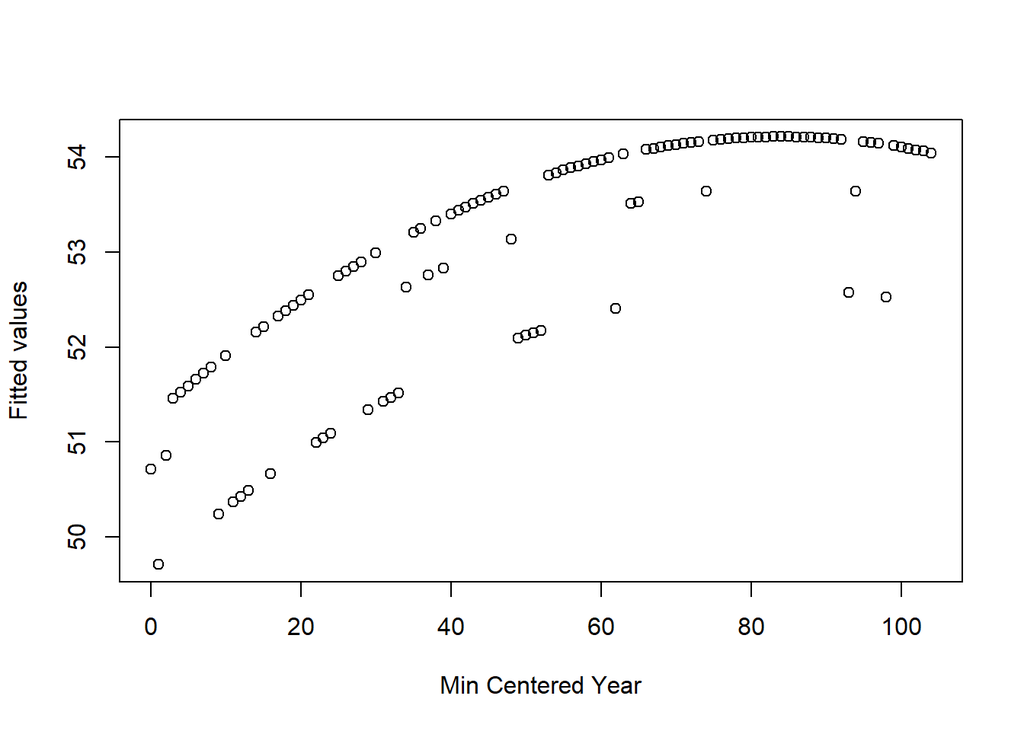

```r
plot(y = regderby2$fitted.values, x = kderby$Year_C, xlab ="Min Centered Year", ylab = "Fitted values")
```

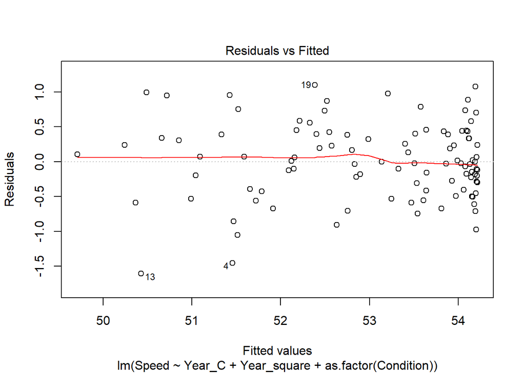

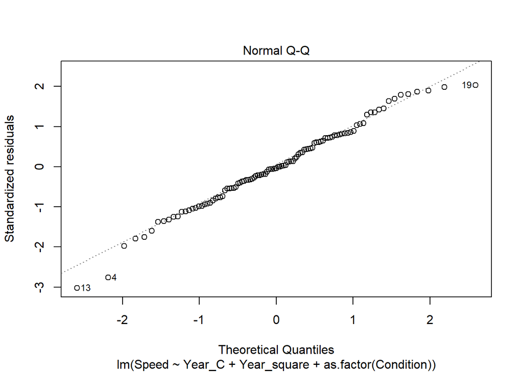

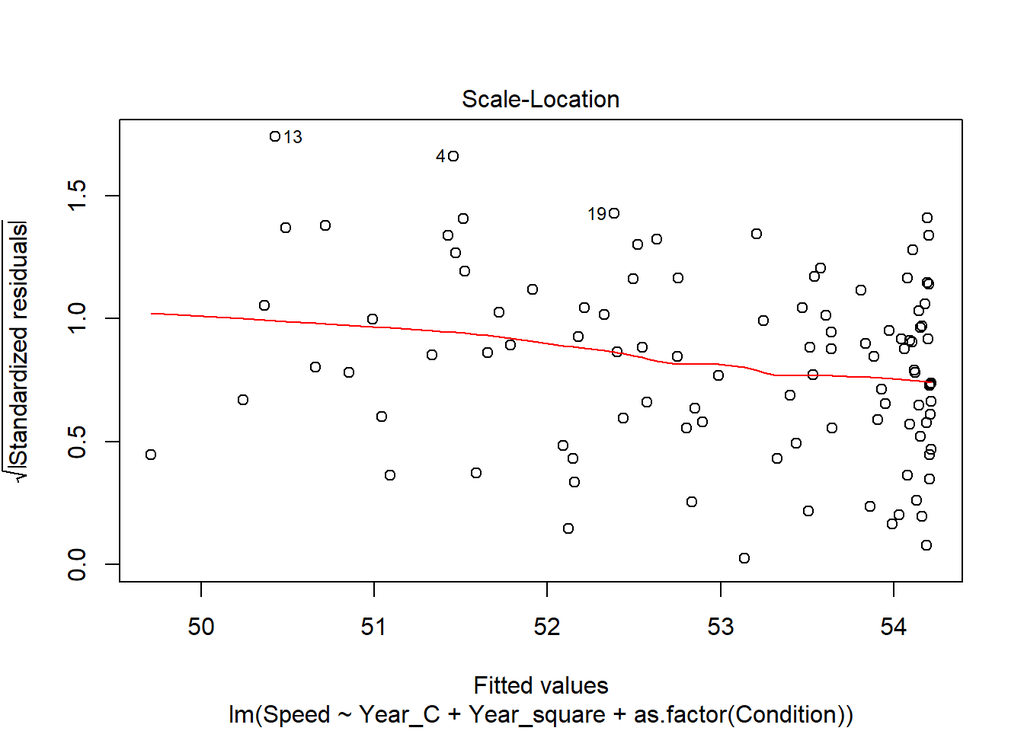

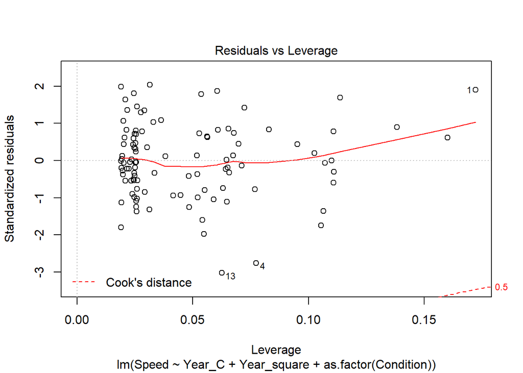

```r
plot(regderby2)
```

We can see that the residual plot shows a constant variance.

The qq plot shows the end points do not fall on the line and hence creates a doubt if the residual exhibit normal distribution.

Limiations: Taking the square of year makes the model hard to interpret. The qq plot has some points that are not on the line and hence creates doubt if it staisfies normal ditribution.